# 452_Assignment_1

Shaolong (Fred) Xue

2023-01-09

```r
library(stringr)
library(tidyr)
```

#### **Question 1**

```r
# setting seed to last 4 phone number
set.seed(7457)

# setting up a 10000 x 1001 matrix
m1 <- matrix(rnorm(10000*1001, 0, 1), nrow = 10000, ncol = 1001)
```

#### **Question 2**

```r
# creating column name list for X variables
Xnames <- str_c("X", str_pad(1:1000, width = 1))

# renaming the matrix
colnames(m1) <- c("Y", Xnames)
```

#### **Question 3**

```r
# converting matrix to a data frame for regression
m1df <- as.data.frame(m1)

# regressing Y on all X variables, with intercept
model <- glm(m1df$Y ~ ., data = m1df)

# summary of models
summary(model)
```

```
##
## Call:
## glm(formula = m1df$Y ~ ., data = m1df)
##
## Deviance Residuals:
##     Min       1Q   Median       3Q      Max
## -4.0139  -0.6357  -0.0019   0.6562   3.7803
##
## Coefficients:
##               Estimate Std. Error t value Pr(>|t|)
## (Intercept)  5.980e-03  1.062e-02   0.563  0.57354
## X1          -5.324e-04  1.060e-02  -0.050  0.95997
## X2           2.303e-03  1.072e-02   0.215  0.82986
## X3          -9.976e-03  1.057e-02  -0.944  0.34517
## X4           1.460e-02  1.068e-02   1.367  0.17151
## X5          -1.682e-03  1.070e-02  -0.157  0.87504
## X6          -4.328e-03  1.058e-02  -0.409  0.68248
## X7          -7.963e-03  1.067e-02  -0.746  0.45567
## X8          -3.994e-03  1.055e-02  -0.379  0.70504
## X9           4.632e-03  1.061e-02   0.437  0.66240
## X10          1.224e-02  1.069e-02   1.146  0.25200
## X11          7.345e-03  1.061e-02   0.692  0.48876
## X12         -3.152e-03  1.079e-02  -0.292  0.77032
## X13          1.014e-02  1.043e-02   0.973  0.33066
## X14          9.512e-03  1.065e-02   0.893  0.37165
## X15         -3.595e-04  1.055e-02  -0.034  0.97283
## X16         -7.205e-03  1.066e-02  -0.676  0.49910
## X17          7.682e-03  1.067e-02   0.720  0.47142
## X18         -1.034e-03  1.060e-02  -0.098  0.92229
## X19         -6.473e-03  1.062e-02  -0.609  0.54233
## X20         -3.158e-03  1.052e-02  -0.300  0.76416
## X21         -8.738e-03  1.056e-02  -0.828  0.40785
## X22          2.000e-02  1.078e-02   1.856  0.06354 .
## X23         -5.704e-03  1.062e-02  -0.537  0.59125
## X24          4.815e-03  1.070e-02   0.450  0.65270
## X25          2.375e-03  1.069e-02   0.222  0.82429
## X26          1.616e-03  1.068e-02   0.151  0.87971
## X27          8.545e-03  1.069e-02   0.799  0.42424
## X28          1.395e-02  1.069e-02   1.305  0.19200
## X29          5.559e-03  1.073e-02   0.518  0.60443
```

[output cut: 966 more lines]

```
## X996         3.447e-03  1.060e-02   0.325  0.74514
## X997        -3.179e-03  1.063e-02  -0.299  0.76490
## X998         5.142e-03  1.069e-02   0.481  0.63062
## X999        -3.972e-03  1.058e-02  -0.376  0.70722
## X1000        3.548e-03  1.069e-02   0.332  0.73999
## ---
## Signif. codes:  0 '***' 0.001 '**' 0.01 '*' 0.05 '.' 0.1 ' ' 1
##
## (Dispersion parameter for gaussian family taken to be 1.015823)
##
##     Null deviance: 10070.0  on 9999  degrees of freedom
## Residual deviance:  9141.4  on 8999  degrees of freedom
## AIC: 29485
##
## Number of Fisher Scoring iterations: 2
```

Our data here is just pure randomness. Intercept doesn’t really convey any practical meaning and, thus,it doesn’t matter that much if the true intercept is zero or not. But I’m choosing to keep the intercept because it nonetheless gives the model more freedom to capture all patterns in the data (even it’s simply randomness).

#### **Question 4**

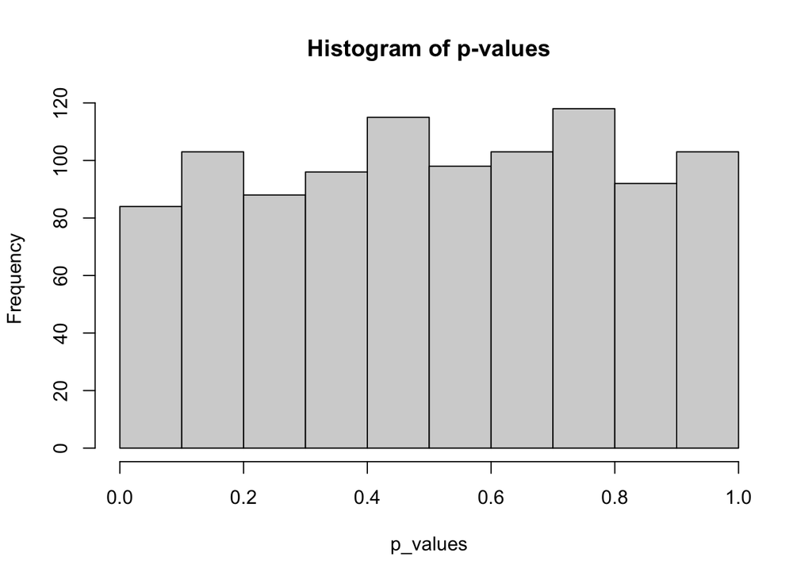

```r
p_values <- summary(model)$coefficients[-1,4]

# histogram of p-values from model with intercept
hist(p_values, main = "Histogram of p-values")
```

The p-values of our model seem to be uniformly distributed.

#### **Question 5**

```r
# 4 significant variables
table(p_values < 0.01)
```

```
##
## FALSE  TRUE
##   996     4
```

In real significance term, I don’t expect to find any significant variables because the data were drawn randomly from a standard normal distribution. There’s no real meaning to the values. However, in reality, we found a few variables that are statistically significant. This is purely due to chance when we’re testing so many variables. These significance cases are false discoveries.

#### **Question 6**

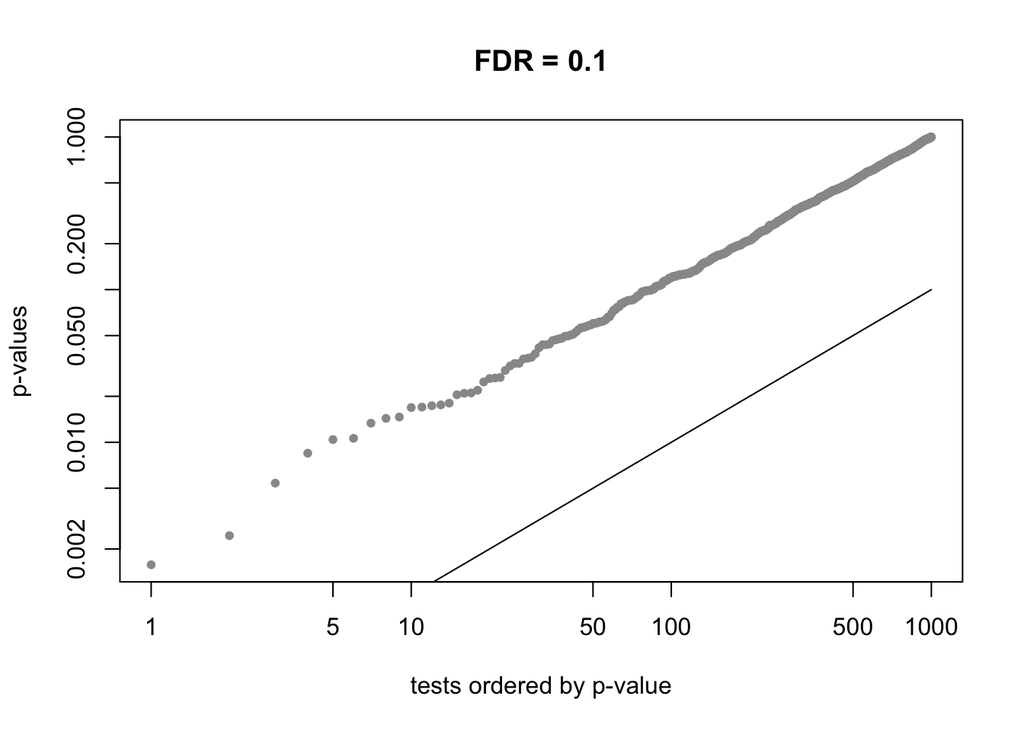

```
## [1] -Inf
```

```r
# I'm using code from the course file, "fdr.R"

## extract p-value cutoff for E[fdf] < q
fdr <- function(pvals, q, plotit = FALSE){
  pvals <- pvals[!is.na(pvals)]
  N <- length(pvals)

  k <- rank(pvals, ties.method="min")
  alpha <- max(pvals[ pvals <= (q*k/N) ])

  if(plotit){
    sig <- factor(pvals <= alpha)
    o <- order(pvals)
    plot(pvals[o], log="xy", col=c("grey60","red")[sig[o]], pch=20,
      ylab="p-values", xlab="tests ordered by p-value", main = paste('FDR =',q))
    lines(1:N, q*(1:N) / N)
  }

  return(alpha)
}

fdr(p_values, 0.1, plotit = TRUE)
```

After applying the BH procedure to control the FDR, we actually find no real significant variables. 0 out of 1000. This is indeed expected because we know that the nature of the data is pure random noise. And this further confirms the fact that the previously tested significant variables are the result of mere statistical chance in the abundance of tests. .

#### **Question 7**

```r
autos <- read.csv("autos.csv")

summary(autos)
```

```
##      make            fuel_type          aspiration        num_of_doors
##  Length:193         Length:193         Length:193         Length:193
##  Class :character   Class :character   Class :character   Class :character
##  Mode  :character   Mode  :character   Mode  :character   Mode  :character
##
##
##
##   body_style        drive_wheels       engine_location      wheel_base
##  Length:193         Length:193         Length:193         Min.   : 86.60
##  Class :character   Class :character   Class :character   1st Qu.: 94.50
##  Mode  :character   Mode  :character   Mode  :character   Median : 97.00
##                                                           Mean   : 98.92
##                                                           3rd Qu.:102.40
##                                                           Max.   :120.90
##      length          width           height       curb_weight
##  Min.   :141.1   Min.   :60.30   Min.   :47.80   Min.   :1488
##  1st Qu.:166.3   1st Qu.:64.10   1st Qu.:52.00   1st Qu.:2145
##  Median :173.2   Median :65.40   Median :54.10   Median :2414
##  Mean   :174.3   Mean   :65.89   Mean   :53.87   Mean   :2562
##  3rd Qu.:184.6   3rd Qu.:66.90   3rd Qu.:55.70   3rd Qu.:2952
##  Max.   :208.1   Max.   :72.00   Max.   :59.80   Max.   :4066
##  engine_type        num_of_cylinders  engine_size    fuel_system
##  Length:193         Min.   : 3.00    Min.   : 61.0   Length:193
##  Class :character   1st Qu.: 4.00    1st Qu.: 98.0   Class :character
##  Mode  :character   Median : 4.00    Median :120.0   Mode  :character
##                     Mean   : 4.42    Mean   :128.1
##                     3rd Qu.: 4.00    3rd Qu.:146.0
##                     Max.   :12.00    Max.   :326.0
##       bore           stroke      compression_ratio   horsepower
##  Min.   :2.540   Min.   :2.070   Min.   : 7.00     Min.   : 48.0
##  1st Qu.:3.150   1st Qu.:3.110   1st Qu.: 8.50     1st Qu.: 70.0
##  Median :3.310   Median :3.290   Median : 9.00     Median : 95.0
##  Mean   :3.331   Mean   :3.249   Mean   :10.14     Mean   :103.5
##  3rd Qu.:3.590   3rd Qu.:3.410   3rd Qu.: 9.40     3rd Qu.:116.0
##  Max.   :3.940   Max.   :4.170   Max.   :23.00     Max.   :262.0
##     peak_rpm       city_mpg      highway_mpg        price
##  Min.   :4150   Min.   :13.00   Min.   :16.00   Min.   : 5118
##  1st Qu.:4800   1st Qu.:19.00   1st Qu.:25.00   1st Qu.: 7738
##  Median :5100   Median :25.00   Median :30.00   Median :10245
##  Mean   :5100   Mean   :25.33   Mean   :30.79   Mean   :13285
##  3rd Qu.:5500   3rd Qu.:30.00   3rd Qu.:34.00   3rd Qu.:16515
##  Max.   :6600   Max.   :49.00   Max.   :54.00   Max.   :45400
```

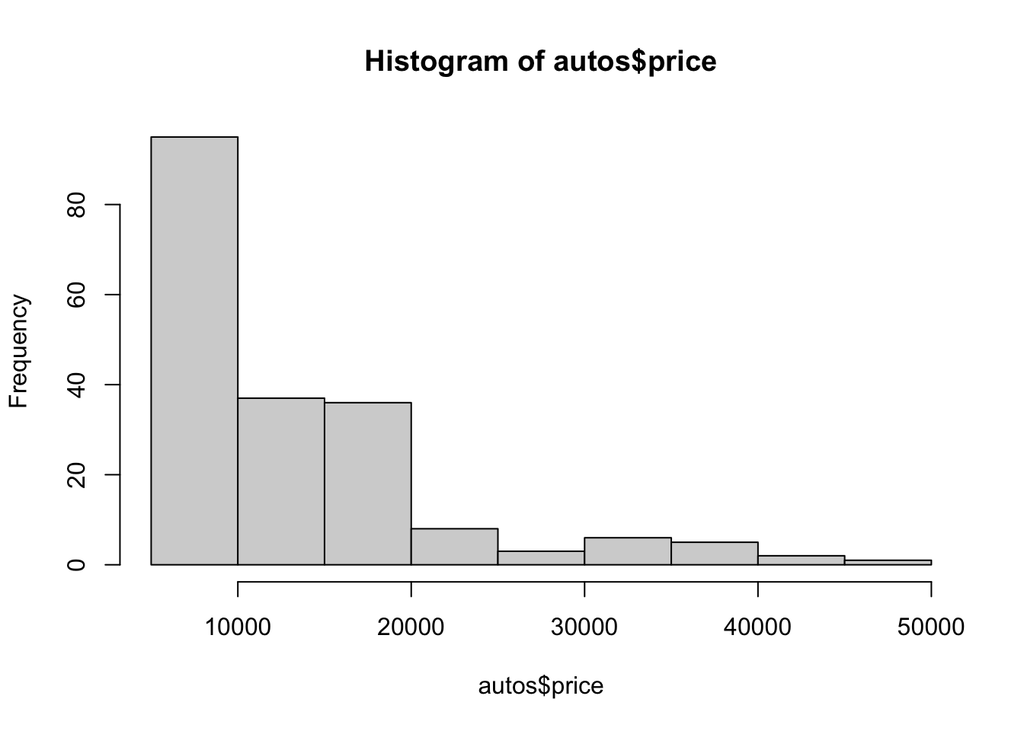

```r
# most of the vehicles were priced around $10,000.
hist(autos$price)
```

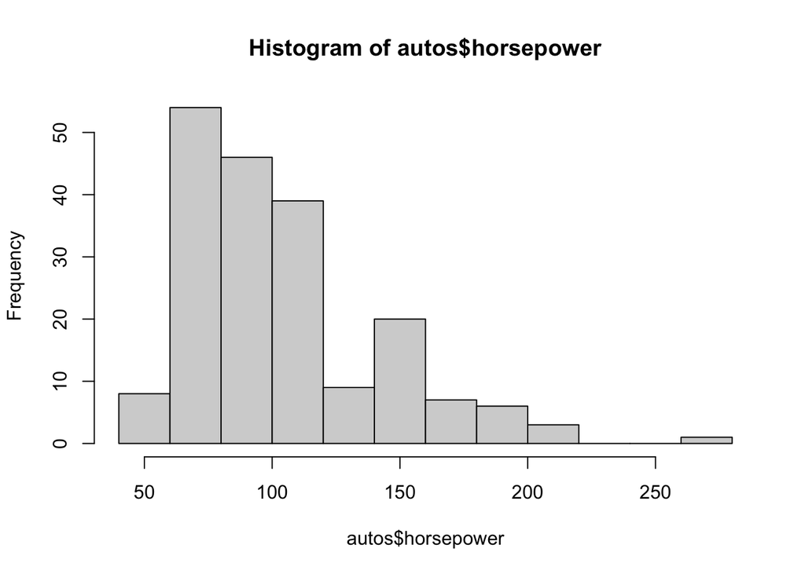

```r
# bi-modal: most of the vehicles had around 80 hp; another cluster around 150hp
hist(autos$horsepower)
```

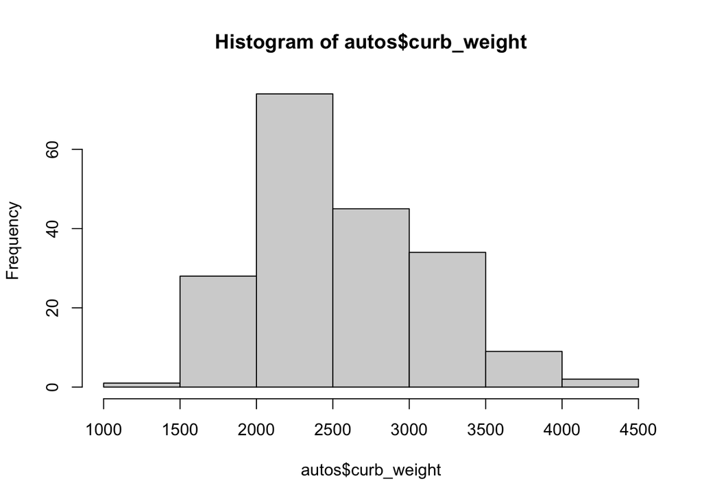

```r
# most of the vehicles weight around 2000-2500 lb
hist(autos$curb_weight)
```

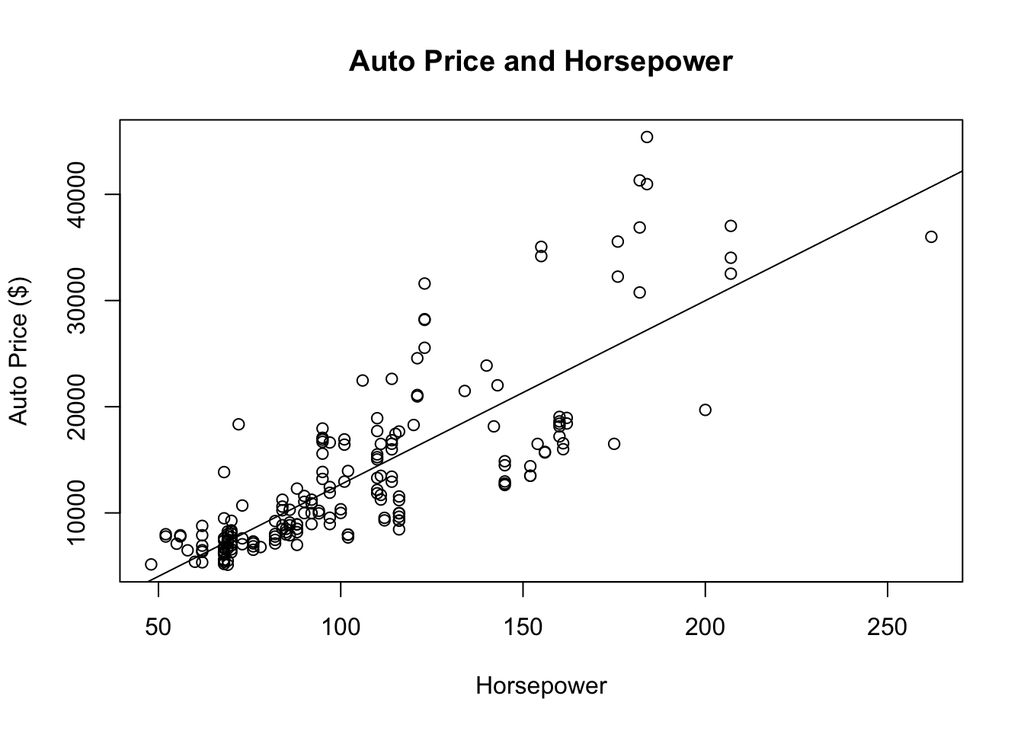

```r
# price and horsepower are positively correlated
plot(autos$horsepower, autos$price,
     main = "Auto Price and Horsepower",
     xlab = "Horsepower",
     ylab = "Auto Price ($)")
abline(lm(autos$price ~ autos$horsepower))
```

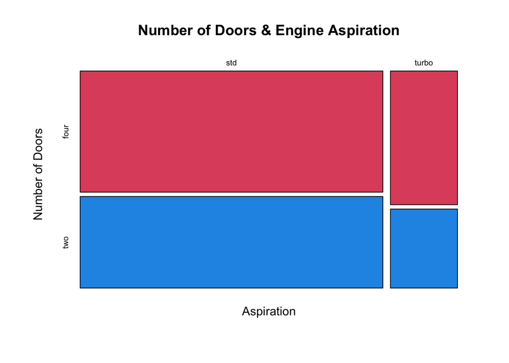

```r
# Four-door vehicles had more turbo charged engines. Surprising...
mosaicplot(~ autos$aspiration + autos$num_of_doors,
           main = "Number of Doors & Engine Aspiration",
           xlab = "Aspiration", ylab = "Number of Doors",
           color = c(2,4))
```

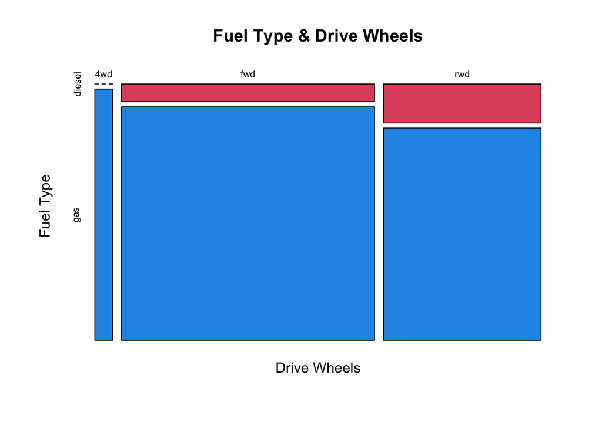

```r
# Most vehicles ran on gas; no 4wd vehicles used diesel fuel.
mosaicplot(~ autos$drive_wheels + autos$fuel_type,
           main = "Fuel Type & Drive Wheels",
           xlab = "Drive Wheels", ylab = "Fuel Type",
           color = c(2,4,5))
```